[output not shown]

# Background and Resarch Questions

Disciplinary infractions during incarceration reflect both individual inmate wellbeing and broader institutional safety. This report analyzes prisoner outcomes during their prison sentences and examines how a range of factors influence the infractions during incarceration. This analysis is designed to give prison administrators and policymakers a clearer picture of where targeted investment in mental health services could have the greatest impact. Using a current metric of wellness through violations has been shown to be predictive of how prisoner behavior may evolve after their sentence is over. Rule violations during incarceration offer insight into inmate wellbeing and institutional stability that earlier outcome studies have largely overlooked.

This analysis is intended to help identify areas where inmates are at their most vulnerable so that limited prison resources can be used in the most efficient ways. By using rule violations, we hope to push for earlier intervention in mental health treatment and identifying at-risk individuals. This is a shift from other analyses which often look at post-sentencing outcomes to determine wellness.

Understanding who is most at risk of violations and the role mental health plays in that risk is the missing piece that this project addresses. There is discussion surrounding mental health in the general population that rarely considers the prison population. The rates of mental health issues are much higher for incarcerated people and those with any kind of a prison record. While treatment opportunities do exist for prisoners, the offerings typically do not have a large variety or a high level of quality. In this report we assess and communicate findings about treatment at a broad level, as there was no way to identify what type of treatment a prisoner had received. The result is a broad base look at the pervasiveness of mental health issues and how treatment is interacting with other factors to change rule violation outcomes.

In the first phase of our analysis, we sought to identify which variables best distinguish high and low predicted infraction risk, investigating potentially influential demographic, criminal justice, and socioeconomic characteristics (gender, years of education, offense type, number of children, etc.), and specifically whether inmates received mental health treatment (MHT) post-admission.

In the second phase of our analysis, we sought to reveal which demographic and clinical factors drive higher infraction risk and identify potential gaps in prison mental health services that could lead to policy change(s).

Statistically, the research questions are important because they test which variables are most useful for infraction risk prediction or explanation in the presence of several predictors at a time. They also help to distinguish prediction from explanation, which is important because a variable can statistically be associated with risk without being a direct cause.

Substantively, the research questions are important because infractions impact prison safety, management, expense, and inmate outcomes. Investigating demographic, criminal justice, and mental health treatment factors (among others) can identify which groups are at higher risk and whether prison mental health services are reaching those who need them most.

# Data Description

We used data from the *Survey of Prison Inmates (SPI), United States, 2016 (ICPSR 37692) Data Set for Public-Use*. Data was collected through in-person interviews with prisoners incarcerated in state correctional facilities, as well as from inmate records, intake forms, surveys, questionnaires, screenings, etc.

The Principal Investigator of this study was the Bureau of Justice Statistics Conducted by the Bureau of Justice Statistics, this was conducted such that policymakers could address shortcomings of correctional institutions. Sample selection was done carefully, with a two stage probability sample, where about 20,000 inmates were chosen to represent about 1.5 Million inmates within the prison system. Data was collected using Computer-Assisted Personal Interviewing to assist with human and data entry error with a relatively high response rate (70%).

Questions regarding personal feelings on past wrongdoings may lead to response biases as inmates may feel they want to lie to “look good.” Inmates were assured that answers were completely anonymous and that their identity was protected, to reduce bias.

Our model is composed of variables related to mental health, treatment, alcohol use, and a host of controls that are unrelated to treatment. The variable that outlines the number of diagnoses an inmate has is highly relevant to our analysis, as it serves as a proxy for severity of someone’s mental condition. People who are diagnosed with more mental health issues are expected to struggle more in and outside of prison. On top of that, the mental health treatment status of an inmate is important to this work as it is one of the focal parameters. It indicates if a person has received mental health treatment during their incarceration period or not. Additionally we are able to observe if the inmate has had an alcohol abuse problem or if they have ever participated in an alcohol treatment program.

In terms of the variables outside of treatment and mental health, education is one of the most important variables in our analysis. In the exploratory data analysis of the SPI, 78 percent of prisoners had a high school diploma or less. In the second stage model, we find education to be one of the strongest predictors of rule violations. Additionally, we find that the number of times a person is arrested is highly significant. This is related to the idea of repeated violations of legal rules that likely transfers over to prison-time violations.

Many of the variables were suppressed due to privacy reasons and therefore had to be removed because they were unusable. Additionally, all categorical variables had extra descriptions, i.e. “(1) 1 = Yes” as an observation, and therefore must be flattened. Furthermore, many observations were missing for various reasons with codes to specify why, but for our purposes, we flattened them all to “0” or NA as the reason for missing was not relevant to this project.

## Exploratory Data Analysis

We conducted exploratory data analysis to further our understanding of the variables in our data set. Using data visualizations of the distribution of variables and correlation matrices allowed us to see the range of outcomes for prison inmates across variables like education, mental health treatment, and gender. Identifying if there are differences in sub groups was informative to seeing the variation across risk groups of inmates for prison violations.

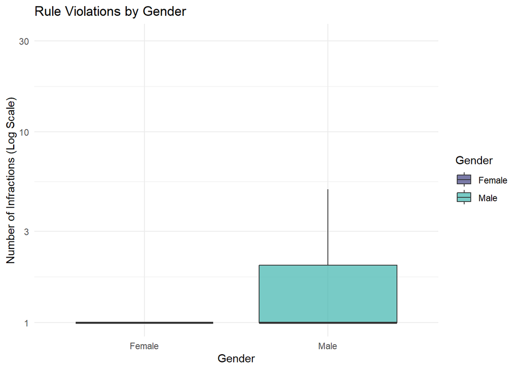

The above figure is a boxplot of female versus male inmates from the sample. In exploration of what kind of variation there might be between inmate subgroups, we assessed gender as the literature had often noted strong differences in inmate behavior based on gender. The female prison population has a much more concentrated number of violations around zero in comparison to the male population. The male inmates share a similar median around one rule violation, but have a much larger spread of data compared to the female inmates. This indicated that gender would be an important demographic variable to include in our model.

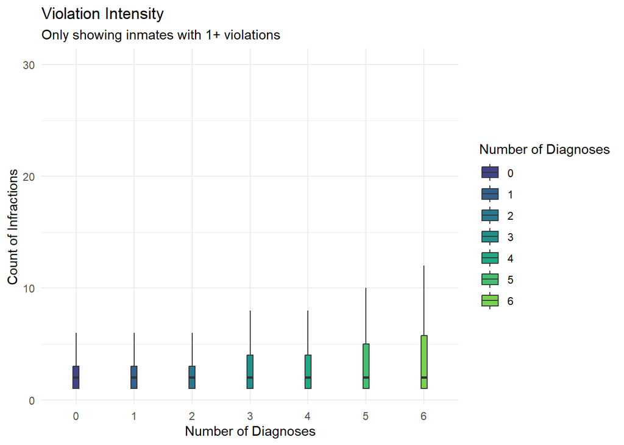

The data includes variables that detail if a prisoner has ever received a diagnosis of bipolar disorder, depression, schizophrenia, anxiety, PTSD, and a host of other mental health issues. We created a variable that summarizes the number of diagnoses based on the existing diagnoses an inmate has. The above boxplot shows a moderate infraction count for those with two or fewer diagnoses, but a noticeable jump in spread occurs at the third diagnoses. There is a noticeable increase in the count of infractions after the third diagnosis, a trend that continues up until the sixth mental health diagnoses.

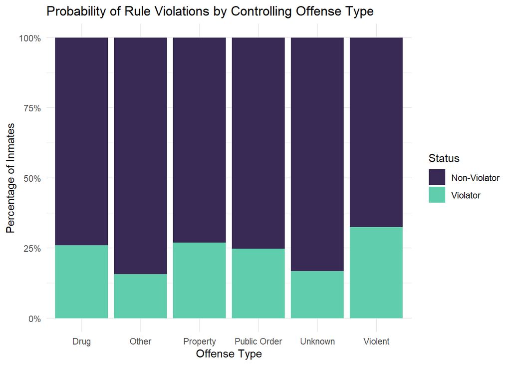

The offense type also had an interesting distribution. Intuition suggested that the most violent offenses would also have the highest shares of rule violaters compared to non-violators. This holds true, but three other offense types have similarly high shares of rule violators: drug, property, and public offenses. This identifies a meaningful difference in the distribution of violators motivating why offense type is included in our later regressions.

# Methods

Our analysis uses a two-stage modeling approach to answer our research questions. In the first stage, we implement a logistic regression model to classify inmates into “high” and “low” predicted risk groups based on whether they are at risk of committing rule violations. This model uses demographic, criminal justice, and mental health-related variables to estimate the probability that an individual falls into the at-risk category. By transforming the outcome into a binary indicator, this stage allows us to identify which characteristics are most predictive of elevated violation risk and to create a clear distinction between higher and lower risk individuals.

In the second stage of our analysis, we used a negative binomial regression model to the subset of inmates classified as high predicted risk. In this stage, the outcome variable is the number of rule violations, which is a count variable with a wide range of possible values. The negative binomial model allows us to estimate how individual characteristics are associated with variation in the number of infractions within this higher-risk group. This two-stage approach allows us to first identify who is at risk and then more precisely model the intensity of rule violations among those individuals.

The negative binomial regression is the best fit for our second stage because our outcome variable is a count of rule violations that shows clear overdispersion. When we initially used a Poisson model, we found that the model had a much higher AIC and did not appropriately account for the variance in the data, which was much larger than the mean. Because the Poisson model assumes that the mean and variance are equal, this led to a poor fit for our data. The negative binomial model relaxes this assumption and allows the variance to exceed the mean, making it more appropriate for modeling the distribution of infractions in our sample.

Inspection of the upper tail of the distribution revealed several extreme values (e.g., 50, 54, 60, 63, 70, 78, 90, 100, 120, 175, 250) that were substantially larger than the rest of the data. These values were sparsely distributed and exhibited large jumps, suggesting they may reflect institutional recording practices or aggregation of infractions rather than comparable counts of individual violations. To reduce the influence of these extreme observations on model estimation, values above 50 infractions were excluded from the analysis.

Additionally, the structure of our data includes a high number of observations at or near zero, along with a smaller number of individuals with a large number of violations. The negative binomial model is better suited to handle this type of dispersion and skewness, allowing for more accurate and stable coefficient estimates. This is particularly important given the wide range of possible outcomes for the number of infractions.

We also considered alternative modeling approaches. A Poisson regression was initially explored, but ultimately rejected due to its poor model fit and inability to handle overdispersion. We also considered using a single-stage model rather than a two-stage approach, but this would have forced us to model both the probability of being at risk and the number of infractions simultaneously, which could reduce interpretability and model accuracy given the zero-inflated nature of the data. By separating the process into two stages, we are able to more clearly distinguish between the factors that predict risk and the factors that influence the number of violations among high-risk individuals.

In a logistic regression the outcome variable has to be binary, with a 0 or 1 outcome indicator. To achieve this we created the “at risk” variable. This variable captures if prisoners are expected to commit rule violations, sorted into a yes or no grouping associated with a 1 and 0. We also do not believe that the observations are correlated at all. Each inmate should be an independent, randomly sampled unit from across the state prison population. There are no federal prisoners represented in our data, but this sample of people should be representative of the larger prison population and not lead to biased results from a dependence in observation responses. To avoid multicollinearity in the logistic model, we reviewed exploratory data analysis to evaluate if any variables had a strong relationship with each other. We found that bipolar disorder and a depression diagnosis were highly correlated with each other. The depression variable was noticeably correlated with the other diagnoses, this may be due to a high presence of depression found across those with other mental health issues.

The negative binomial regression also can not be used if there is a high presence of multicollinearity. We performed exploratory data analysis to look at inter-variable correlation rates. To ensure that no two variables were accounting for each other we checked a correlation matrix and heatmap of the explanatory variables and did not include those with correlations above |0.7|. This was done by evaluating the different explanatory plots from the logistic regression and then checked the VIF levels to ensure they were below 10.

# Results

Our Final First Stage Model is as follows:

$logit(P(At Risk = 1)) = \beta_0+\beta_1Years of Education+\beta_2ADD/ADHD+\beta_3Gender:Male+\beta_4Offense:Other+\beta_5Offense:Property+\beta_6Offense:Public Order+\beta_7Offense:Unknown+\beta_8Offense:Violent+\beta_9Children+\beta_{10}Times Arrested+\beta_{11}Mental Health Treatment+\beta_{12}Alcoholism$

The first stage of analysis employed logistic regression, a binomial family logit link model. The reported coefficients, $\beta$, represent the change in log-odds of being classified as “at risk” for every one-unit increase in the predictor variable. These estimates are modeled according to the logit link function:

$logit(p) = \ln(\frac{p}{1-p}) = \beta_0+\beta_1x_1...\beta_kx_k$

where $p$ is the probability of risk classification

After conducting a Likelihood-Ratio Test on our model, we find that our final model has a deviance score (null vs residual) of 4685 on 12 degrees of freedom and a p-value less than 0.001. This model was fit on $n=15,450$ observations with 1708 dropped/deleted observations. Over 90% are due to alcoholism.

This indicates our full model significantly outperformed the null model and the combination of clinical and demographic factors provides substantial predictive power for inmate infraction risk. Overall, our model had a 73% classification accuracy (classification of inmates who had infractions or not) and with an AUC of 0.797, it demonstrates a good amount of discriminative ability, correctly distinguishing between at risk and non-at risk individuals about 80% of the time when presented with a random pair of one positive and one negative case.

Stage 1 Confusion Matrix

| Classification | Observed: No Infraction (0) | Observed: At Risk (1) |
| --- | --- | --- |
| Predicted: Low Risk (0) | 5,361 | 2,365 |
| Predicted: High Risk (1) | 1,755 | 5,969 |

Note:  
Overall Accuracy: 73.3% | Sensitivity: 75.3% | Specificity: 71.6% | P-Value: < .001 | No Information Rate (NIR): 53.9%

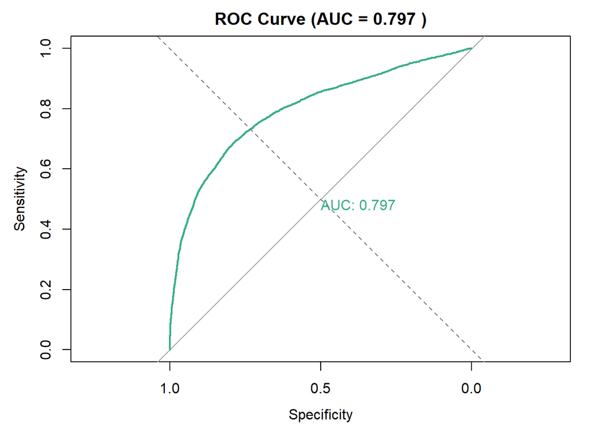

The model diagnostics state that the most significant predictors are ADD/ADHD, Male Gender, Times Arrested, and Mental Health Treatment. Out of these, the predictors with the largest effect size are ADD/ADHD with 1.33, Male Gender with -0.938, and Mental Health Treatment with 2.201.

Significant Predictors

| Variable | Estimate | OR | Z_Value | 95% Confint IRR |
| --- | --- | --- | --- | --- |
| ADD/ADHD | 1.3389959 | 3.8152109 | 28.22076 | (3.48 - 4.19) |
| Male Gender | -0.9386538 | 0.3911541 | -19.65422 | (0.36 - 0.43) |
| Mental Health Treatment | 2.2016663 | 9.0400643 | 43.74620 | (8.2 - 9.98) |

The final Second Stage Model is as follows:

$ln(Infractions) = \beta_0+\beta_1Race:Black+\beta_2Race:Hispanic+\beta_3Race:Multiracial+\beta_4Race:Other+\beta_5Race:White+\beta_6NumberofDiagnoses+\beta_7ArmedForces+\beta_8TimesArrested+\beta_9YearsofEducation+\beta_{10}ADD/ADHD+\beta_{11}Homeless+\beta_{12}Children+\beta_{13}MentalHealthTreatment+\beta_{14}Alcoholism+\beta_{15}AlcoholTreatment+\beta_{16}Gender:Male+\beta_{17}+ \beta_{18}Offense:Other+\beta_{19}Offense:Property+\beta_{20}Offense:PublicOrder+\beta_{21}Offense:Unknown+\beta_{22}Offense:Violent+\beta_{23}NumberofDiagnoses*MentalHealthTreatment+\beta_{24}Alcoholism*Alcohol Treatment$

The second stage utilized negative binomial regression with a log link to analyze the infraction frequency within the high-risk subgroup. The coefficients are reported on the log-count scale. Due to the model using the natural log link, the relationship is such:

$\ln(\mu) =\beta_0+\beta_1x_1...\beta_kx_k$

Comparing the 2 models using their goodness-of-fit statistics, it is seen that a negative binomial model is more favorable with a lower AIC and Overdispersion statistic $(\phi)$. The negative binomial model was fitted on the subpopulation of $n = 7,619$ of those rated as “High Predicted Risk.” This was determined by our previous logistic model of those who had a higher predicted probability of having an infraction than the median value of the data set, which was 0.497. 105 observations were not counted, over 90% were deleted due to Race being unavailable.

Model Comparison

| Model | AIC | Deviance | df | Overdispersion |
| --- | --- | --- | --- | --- |
| Poisson | 35484.49 | 2373.456 | 23 | 8.3143945 |
| Negative Binomial | 19761.59 | 385.641 | 23 | 0.2250685 |

Model Statistics

| Variable | Estimate | Std.Error | P.Value | 95% Confint IRR |
| --- | --- | --- | --- | --- |
| ADD/ADHD | 0.6047363 | 0.0637578 | <0.0001 | (1.616 - 2.074) |
| Times Arrested | 0.0079125 | 0.0011492 | <0.0001 | (1.006 - 1.01) |
| Children | -0.3953537 | 0.0588810 | <0.0001 | (0.6 - 0.756) |
| Mental Health Treatment | 0.3248295 | 0.0936386 | 0.00052 | (1.152 - 1.663) |
| Alcoholism | 0.2941803 | 0.0815311 | 0.00031 | (1.144 - 1.575) |
| Offense Type: Unknown | -0.5126795 | 0.1334874 | 0.00012 | (0.461 - 0.778) |

[figure not shown]

Diagnostic plots suggest that the negative binomial model reproduces the broad distributional form of the outcome, but does not fully capture the allocation of probability among the smallest counts. The largest prediction errors occur at 0, 1, and 2 infractions, while fit improves for higher counts. This indicates that the model is adequate for the general shape of the count distribution but less accurate in modeling the concentration of low-count outcomes.

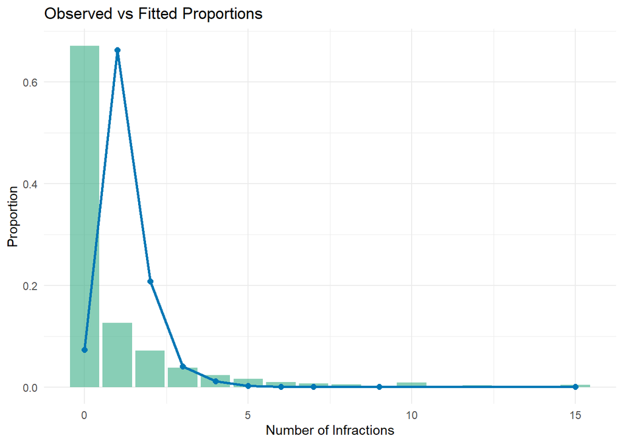

# Interpretation

Treatment variables display different patterns. Mental health treatment remains positively associated with infraction counts among high‑risk inmates. The coefficient of roughly 0.31 (IRR $\approx$ 1.37) indicates that treated high‑risk inmates have about 37% more infractions than untreated high‑risk inmates, conditional on diagnoses and other controls. An interaction between the number of diagnoses and mental health treatment is small and non-significant, suggesting that mental health treatment does not materially alter the relationship between diagnostic burden and infractions in our data. By contrast, alcohol/drug treatment shows a clinically meaningful interaction with alcoholism. While the main effect of alcohol/drug treatment is negligible overall, the Alcoholism × Alcohol/Drug Treatment interaction term is negative and statistically significant (IRR $\approx$ 0.76), indicating that among inmates with alcoholism, those who receive alcohol/drug treatment have approximately 24% fewer expected infractions than alcoholic inmates who do not receive such treatment.

With respect to services, our findings suggest that mental health treatment is being targeted toward the highest‑risk inmates but, in these observational models, is not associated with lower infraction counts; the positive association likely reflects confounding by severity rather than a harmful effect of treatment. By contrast, alcohol/drug treatment appears to be behaviorally beneficial within the subgroup of inmates with alcoholism, as indicated by the significant interaction term. Taken together, these results support policy recommendations to intensify screening and treatment for alcohol use disorders among high‑risk inmates, to expand or strengthen education‑related programming for this population, to re‑examine the design and delivery of mental health services with respect to behavioral outcomes, and to scrutinize racial and gender disparities in disciplinary practices and infraction recording.

# Limitations

Treatment participation is not randomly assigned, and individuals receiving treatment may differ systematically from those who do not. This introduces potential selection bias that may confound estimated treatment effects. As a result, estimated treatment effects should be interpreted as associative rather than causal, and may reflect underlying differences in inmate characteristics rather than the effect of treatment itself.

Additionally, several variables, including mental health diagnoses and substance use, are self-reported and may be subject to measurement error or misclassification. This is best shown in the “Alcoholism” Variable. A substantial portion of missing data in the SPI is due to this and therefore affected the first-stage logistic model. If missingness in this variable is systematically related to unobserved characteristics, then the resulting sample may not be representative of the full inmate population. Many of the drug variables were missing and ultimately, had to be taken out of the model due to an excessive amount of observations being unusable. This introduces the potential for selection bias and may lead to biased coefficient estimates, particularly for variables correlated with substance use and disciplinary outcomes.

The second stage model entirely relies on the logistic model to be strong. The initial logistic regression must be a resilient and robust predictor of if a prisoner is in the at risk for high prison violations or not. If the regression turns out to be a weak predictor, then any results from the second stage will be highly criticized for their dependence on a weak dependent variable. The validity of the second stage depends on the predictive performance of the first-stage model. If the classification model performs poorly, misclassification of individuals into the high-risk group may introduce bias into the second-stage estimates.

An important limitation of trying to predict rule violations is that we do not know exactly when the violations occurred. The relevancy of timing is important to highlight, but the data did not allow for highly granular details on when and what kind of rule violations were committed. There may have been important information on the severity of the infractions that we are missing in our model or outcomes. Given the limits of our data themself we felt that the reduced form model will still yield general trends that are important for prison populations but won’t identify what kind of rule violations are occurring. Additionally there is data on location and prison identification that was not available in the publicly accessible data. If we had access to location then we could control for state differences in prison systems and try to limit the scope of the population to a more defined population. This leaves us with very high-level takeaways for a general population of state prison inmates that informs policy makers and stakeholders about general trends rather than specific insights, limiting causal interpretation. These suggest that the results should be interpreted as descriptive and predictive rather than causal.

If there are more zero values than the model expects, the results for beta coefficients will be biased. Given the concentration of the outcome variable’s response around zero there may be bias in our estimates. The high concentration of zero outcomes may indicate potential zero-inflation, which is not explicitly modeled. The two-stage framework partially addresses this by conditioning on high-risk individuals, but it does not fully resolve distributional misspecification. Another limitation of the model is that it is influenced by outliers and skewness. To mitigate the influence of extreme values, observations exceeding 50 infractions were excluded. While these values appeared to be qualitatively different from the majority of the data, their removal may exclude valid high-frequency cases and limit the model’s ability to capture behavior among the most extreme offenders.

# Conclusion

Taken all together, the 2 stage analysis shows that the prison disciplinary risk is shaped primarily by clinical burden and criminal justice history, and not simply by broad socioeconomic background. In the first stage, inmates were most likely to be classified as high-risk when they had markers of greater psychiatric or behavioral severity, such as ADD/ADHD, alcoholism, prior arrests, and post-admission mental health treatment. This suggests that the classification process is strongly tied to observable mental health needs and prior system involvement.

In the second stage, once attention is restricted to inmates already identified as high risk, the intensity of misconduct is driven by a somewhat different set of factors: more prior arrests, greater cumulative mental health disorder diagnoses, alcoholism, lower levels of education, and mental health treatment are all associated with higher expected infraction counts, indicating that both clinical complexity and structural disadvantage continue to matter within the highest risk subgroup. Interestingly, the effect of male gender becomes not significant when in the presence of other variables in the second stage model. Although males make up the majority of the overall sample (approximately 75%), they represent a smaller share of the high-risk group (about 60%). Conversely, females comprise a larger proportion of the high-risk group (approximately 40%) compared to their representation in the full sample (about 25%), indicating that females are disproportionately represented among individuals classified as high risk. Mental health treatment remains positively associated with disciplinary outcomes, but in the context of these observational data this pattern is most consistent with severity-based selection into treatment rather than evidence that treatment worsens behavior. By contrast, alcohol/drug treatment appears to be more promising for the subgroup with alcoholism, as the negative and significant interaction suggests that inmates with alcoholism who receive substance-use treatment accumulate fewer infractions than comparable inmates who do not receive such services.

To reiterate, treatment effects cannot be understood apart from inmate severity. Mental health services appear to be concentrated among those with greatest behavioral and psychiatric needs, while substance-use treatment shows clearer evidence of association with reduced misconduct in the population for whom it is most directly targeted. The disparate behavioral outcomes between mental health treatment and substance use programming may be attributed to differences in sociocultural stigma and voluntary engagement. While mental health services in correctional facilities are often crisis-oriented and carry a clinical ‘labeling’ burden, alcohol and drug treatments frequently utilize peer-support and community-based models. This may facilitate higher-quality engagement and a greater internal motivation for behavioral change, potentially explaining the significant interaction effect observed among inmates with alcoholism. Without the availability of temporal data, causal inference cannot be employed in our study. More broadly, our findings suggest that the inmates most vulnerable to repeated disciplinary problems are those carrying multiple forms of disadvantage at once. The positive correlation between mental health treatment and infractions likely reflects severity-driven selection. Prior justice-system contact, psychiatric burden, substance-use disorder, and, within the high-risk group, marked racial disparities in disciplinary outcomes. As a result, the strongest policy implications of this study are to intensify early screening for alcohol-use disorder, strengthen targeted substance-use treatment for high-risk inmates, expand educational programming as a potential protective factor, and more closely examine whether mental health services are sufficiently aligned with behavioral outcomes.

Future work would benefit from data that include the timing of treatment and infractions, institutional identifiers, and more detailed measures of offense severity, since those additions would make it possible to distinguish more clearly between treatment targeting, treatment effectiveness, and differences in disciplinary practices across facilities. The SPI data includes an extensive list of variables as the survey was very comprehensive. During the exploratory data analysis phase, post-incarceration socioeconomic indicators, specifically employment status and income, were considered as potential outcome measures for mental health treatment efficacy. However, these variables were excluded from the final analysis as they are outside the data collection scope of the Survey of Prison Inmates. Perhaps this could be an angle for data collection to find relationships between efficacy outside of prison.

# Appendix A: Data Dictionary

Codebook: Variable Descriptions and Coding

| Variable Name | Original Code | Type | Description | Coding | Source |
| --- | --- | --- | --- | --- | --- |
| **Derived Variables** |  |  |  |  |  |
| at_risk | Derived | Binary (0/1) | Binary indicator from median split of logistic risk probability | 1 = Above median predicted risk probability, 0 = Below median | Derived from Stage 1 logistic model predictions |
| num_diagnoses | Derived | Numeric | Count of 6 specific mental health diagnoses | 0-6 (sum of: Bipolar, Depression, Schizophrenia, PTSD, Anxiety, and Personality Disorder) | Derived from psychiatric screening |
| MHTx:num_diagnoses | Interaction | Numeric | Mental Health Treatment x Diagnosis Count interaction | Product: Mental Health Treatment x num_diagnoses | Model-derived interaction |
| Alcoholism:DrugTx | Interaction | Numeric | Alcoholism x Substance Treatment interaction | Product: Alcoholism x Alcohol/Drug Treatment | Model-derived interaction |
| **Outcome & Continuous Predictors** |  |  |  |  |  |
| Number Infractions | V1398 | Numeric | Total count of disciplinary infractions during incarceration | Continuous (0-250+) | Prison disciplinary records |
| Times Arrested | V0909 | Numeric | Lifetime number of prior arrests | Continuous (count, negatives → NA) | Criminal history records |
| Years of Education | V0935 | Numeric | Total years of formal education completed | Continuous (years, negatives → NA) | Self-reported education history |
| **Categorical Predictors** |  |  |  |  |  |
| Race | V1951-V1957 | Factor | Self-reported race/ethnicity at intake | White/Black/Hispanic/Other (Multiracial/Asian/Native Hawaiian/AI/Other collapsed) | Demographic intake form |
| Gender | V1212 | Factor | Self-described gender identity | Male/Female/Transgender/Do not identify as male, female or transgender | Demographic intake form |
| offense_type | V0062 | Factor | Primary instant offense category | Violent/Property/Drug/Public Order | Presentence investigation report |
| Marital Status | V0022 | Factor | Marital status at time of offense | 0-5 (coded levels: Single/Married/Divorced/etc.) | Family status questionnaire |
| **Binary Predictors** |  |  |  |  |  |
| ADD/ADHD | V0942 | Binary (0/1) | Lifetime diagnosis of ADD/ADHD | 0 = No/Never, 1 = Yes (2 → 0 recoded) | Psychiatric screening questionnaire |
| Bipolar | V1185 | Binary (0/1) | Lifetime bipolar disorder diagnosis | 0 = No, 1 = Yes (2 → 0 recoded) | Psychiatric screening |
| Depression | V1186 | Binary (0/1) | Lifetime major depression diagnosis | 0 = No, 1 = Yes (2 → 0 recoded) | Psychiatric screening |
| Schizophrenia | V1187 | Binary (0/1) | Lifetime schizophrenia diagnosis | 0 = No, 1 = Yes (2 → 0 recoded) | Psychiatric screening |
| PTSD | V1188 | Binary (0/1) | Lifetime PTSD diagnosis | 0 = No, 1 = Yes (2 → 0 recoded) | Psychiatric screening |
| Anxiety | V1189 | Binary (0/1) | Lifetime anxiety disorder diagnosis | 0 = No, 1 = Yes (2 → 0 recoded) | Psychiatric screening |
| Personality Disorder | V1190 | Binary (0/1) | Lifetime personality disorder diagnosis | 0 = No, 1 = Yes (2 → 0 recoded) | Psychiatric screening |
| Other Diagnosis | V1191 | Binary (0/1) | Other lifetime mental health diagnosis | 0 = No, 1 = Yes (2 → 0 recoded) | Psychiatric screening |
| Alcoholism | V1265 | Binary (0/1) | Lifetime alcohol dependence diagnosis | 0 = No, 1 = Yes (2 → 0 recoded) | Substance use disorder assessment |
| Armed Forces | V0023 | Binary (0/1) | U.S. military service history | 0 = No, 1 = Yes (2 → 0 recoded) | Military service verification |
| Homeless | V0958 | Binary (0/1) | Housing instability prior to arrest | 0 = Stably housed, 1 = Homeless (2 → 0 recoded) | Pretrial housing assessment |
| Children | V0982 | Binary (0/1) | Has minor dependent children | 0 = No, 1 = Yes (2 → 0 recoded) | Family responsibility assessment |
| Mental Health Treatment | V1204 | Binary (0/1) | Received mental health treatment during incarceration | 0 = No treatment received post-admission, 1 = Received MHT during prison stay (2 → 0 recoded) | Prison mental health treatment records |
| Alcohol/Drug Treatment | V1374 | Binary (0/1) | Received substance abuse treatment during incarceration | 0 = No treatment received post-admission, 1 = Received substance treatment during prison (2 → 0 recoded) | Prison substance abuse treatment records |

# Appendix B: Model Summary Outputs

```
## Stage 1 Logistic Model
```

```
##
## Call:
## glm(formula = at_risk ~ Years.of.Education + ADD.ADHD + Gender +
##     offense_type + Children + Times.Arrested + Mental.Health.Treatment +
##     Alcoholism, family = binomial(link = "logit"), data = cleaned2,
##     na.action = na.exclude)
##
## Coefficients:
##                           Estimate Std. Error z value Pr(>|z|)
## (Intercept)              -0.105439   0.111897  -0.942 0.346044
## Years.of.Education       -0.006716   0.007237  -0.928 0.353398
## ADD.ADHD                  1.338996   0.047447  28.221  < 2e-16 ***
## GenderMale               -0.938654   0.047758 -19.654  < 2e-16 ***
## offense_typeOther         0.260657   0.350827   0.743 0.457494
## offense_typeProperty      0.235999   0.067435   3.500 0.000466 ***
## offense_typePublic Order  0.193383   0.074804   2.585 0.009732 **
## offense_typeUnknown       0.217762   0.090668   2.402 0.016317 *
## offense_typeViolent       0.120553   0.056052   2.151 0.031498 *
## Children                 -0.086372   0.042271  -2.043 0.041025 *
## Times.Arrested            0.013053   0.001667   7.829 4.94e-15 ***
## Mental.Health.Treatment   2.201666   0.050328  43.746  < 2e-16 ***
## Alcoholism                0.087787   0.038603   2.274 0.022961 *
## ---
## Signif. codes:  0 '***' 0.001 '**' 0.01 '*' 0.05 '.' 0.1 ' ' 1
##
## (Dispersion parameter for binomial family taken to be 1)
##
##     Null deviance: 21322  on 15449  degrees of freedom
## Residual deviance: 16637  on 15437  degrees of freedom
##   (1708 observations deleted due to missingness)
## AIC: 16663
##
## Number of Fisher Scoring iterations: 4
```

[output not shown]

```
##
## Call:
## glm.nb(formula = Number.Infractions ~ Race + num_diagnoses +
##     Armed.Forces + +Times.Arrested + Years.of.Education + ADD.ADHD +
##     Homeless + Children + Mental.Health.Treatment + Mental.Health.Treatment:num_diagnoses +
##     Alcoholism + Alcohol.Drug.Treatment + Alcoholism:Alcohol.Drug.Treatment +
##     Gender + offense_type, data = high_risk_group, init.theta = 0.225068483,
##     link = log)
##
## Coefficients:
##                                        Estimate Std. Error z value Pr(>|z|)
## (Intercept)                           -0.656952   0.519424  -1.265 0.205953
## RaceBlack                              1.035531   0.490403   2.112 0.034721 *
## RaceHispanic                           1.054957   0.511488   2.063 0.039158 *
## RaceMultiracial                        0.730125   0.489379   1.492 0.135714
## RaceOther                              1.330617   0.536754   2.479 0.013175 *
## RaceWhite                              0.439531   0.489300   0.898 0.369034
## num_diagnoses                          0.072018   0.026254   2.743 0.006086 **
## Armed.Forces                          -0.145850   0.119248  -1.223 0.221300
## Times.Arrested                         0.007912   0.001149   6.885 5.76e-12 ***
## Years.of.Education                    -0.037718   0.011595  -3.253 0.001142 **
## ADD.ADHD                               0.604736   0.063758   9.485  < 2e-16 ***
## Homeless                              -0.114640   0.113859  -1.007 0.314003
## Children                              -0.395354   0.058881  -6.714 1.89e-11 ***
## Mental.Health.Treatment                0.324830   0.093639   3.469 0.000522 ***
## Alcoholism                             0.294180   0.081531   3.608 0.000308 ***
## Alcohol.Drug.Treatment                 0.023718   0.074325   0.319 0.749638
## GenderMale                            -0.045294   0.062580  -0.724 0.469206
## offense_typeOther                      0.400541   0.417414   0.960 0.337268
## offense_typeProperty                  -0.014625   0.096488  -0.152 0.879527
## offense_typePublic Order              -0.240554   0.111770  -2.152 0.031380 *
## offense_typeUnknown                   -0.512680   0.133487  -3.841 0.000123 ***
## offense_typeViolent                    0.125330   0.085486   1.466 0.142624
## num_diagnoses:Mental.Health.Treatment -0.014916   0.033334  -0.447 0.654547
## Alcoholism:Alcohol.Drug.Treatment     -0.281589   0.109103  -2.581 0.009853 **
## ---
## Signif. codes:  0 '***' 0.001 '**' 0.01 '*' 0.05 '.' 0.1 ' ' 1
##
## (Dispersion parameter for Negative Binomial(0.2251) family taken to be 1)
##
##     Null deviance: 5716.9  on 7618  degrees of freedom
## Residual deviance: 5331.2  on 7595  degrees of freedom
##   (105 observations deleted due to missingness)
## AIC: 19762
##
## Number of Fisher Scoring iterations: 1
##
##
##               Theta:  0.22507
##           Std. Err.:  0.00655
##
##  2 x log-likelihood:  -19711.59400
```

# References

Prison Policy Initiative. (2026, April). Mental health: Research on the prevalence and treatment of mental illness in the criminal legal system. https://www.prisonpolicy.org/research/mental_health/

Anthropic. (2026). Claude (claude-sonnet-4-6) [Large language model]. Data visualizations generated April 2026. https://claude.ai